# R筆記–(2)基本資料型態

skydome20

2016/03/12

[返回主目錄](https://rpubs.com/skydome20/Table)

# 本篇目錄

1. Integer & Number & Logic & Character
   - 數字 (integer, number)
   - 布林代數 (logic)
   - 字串 (character)
2. Vector & Factor & List
   - 陣列 (vector)
   - 類別變數 (factor)
   - 列表(list)
3. Matrix & Data Frame
   - 矩陣(matrix)
   - 資料框(data frame)
4. 總結
5. (額外)關於賦值

在[安裝完R與RStuio](https://rpubs.com/skydome20/R1-R_and_RStudio) 後，接下來要開始熟悉R的基本觀念。  
要熟悉一個程式語言，第一步就是先了解定義在裡面的資料型態。而在R語言的資料型態，常用的有這些：

- `integer`
- `number`
- `logic`
- `character`
- `factor`
- `vector`
- `list`
- `matrix`
- `data frame`

看起來很多感覺很複雜，但不用擔心，接下來會一邊用例子、一邊介紹這些型態。

# **1. integer，number，logic，character**

這四個型態比較簡單：

- 「整數」的`integer`
- 「實數」的`number`
- 「布林代數」的`logic`
- 「字串」的`character`

## 數字 (integer, number)

若要在R裡宣告一個數字，可以這麼做：

```r
a <- 3
b <- 1.6
```

在這裡，我們稱`a`和`b`為「變數」(或是物件)。  
而`<-`符號，會把右邊的東西，儲存到左邊的名字裡，使左邊的名字變成「變數」(如下圖)

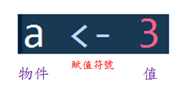

當賦值結束後，我們會需要確認變數的資料型態，這時候可以使用`str()`函式：

```r
str(a)
```

```
##  num 3
```

上面結果顯示，`a`的資料型態是「number」，而非`integer`。有點奇怪，對吧？  
這是因為R預設的數字型態是「number」，意思是，若直接把數字存到變數中，其資料型態是「number」。 那麼，如果想要轉換資料型態，變成`integer`呢？這時候就可以使用`as.integer()`函式：

```r
a <- as.integer(3)
str(a)
```

```
##  int 3
```

如果，想要轉換成`number`的資料型態呢？ 應該猜到了，沒錯，就是使用`as.numeric()`的函示。**(不是`number`，而是`numeric`哦！)**  
更棒的是，這樣的概念可以「舉一反三」！下表就是各種資料型態，所對應的轉換函式：

| 資料型態 | 轉換函式 |
| --- | --- |
| integer | as.integer() |
| number | as.numeric() |
| character | as.character() |
| factor | as.factor() |
| matrix | as.matrix() |
| vector | as.vector() |
| list | as.list() |
| data frame | as.data.frame() |

有時候，我們要確認變數的資料型態，是否為`integer`，這時可以使用`is.integer()`函式：

```r
is.integer(a)
is.integer(b)
```

```
## [1] TRUE
## [1] FALSE
```

`str()`的功能是「顯示資料型態」，而`is.integer()`則是「判斷是否為integer，回傳TRUE/FALSE」。  
當然，這時聰明的人就會思考，是不是也可以舉一反三呢？  
答案是，可以的：

| 資料型態 | 判斷函式 |
| --- | --- |
| integer | is.integer() |
| number | is.numeric() |
| character | is.character() |
| factor | is.factor() |
| matrix | is.matrix() |
| vector | is.vector() |
| list | is.list() |
| data frame | is.data.frame() |

## 布林代數 (logic)

所謂的布林代數(boolean)，代表的是`True`和`False`，常用於邏輯式上的判斷。而在R裡面，以`logic`的資料型態來表示：

```r
a <- TRUE
b <- FALSE
str(a)        #確認a的型態
is.integer(b) #判斷b是不是整數，但b是logic型態，所以回傳FALSE
```

```
##  logi TRUE
## [1] FALSE
```

## 字串 (character)

要定義一個`character`變數的話，注意放在右邊的值，要用雙引號(`" "`)括起來：

```r
professor <- "Dr.Lee"
```

如果沒有括起來，右邊就會視為「變數」。若沒有事先定義的話，就會跳出錯誤訊息：

```r
professor <- Dr.Lee
```

```
## Error in eval(expr, envir, enclos): 找不到物件 'Dr.Lee'
```

換句話說，只要事先定義好變數，那麼變數之間，就可以互相傳遞自己儲存的值：

```r
a <- "Dr.Lee"    # a的資料型態是character
professor <- a   # a是變數，把a存到professor裡
str(professor)   # 確認professor資料型態
```

```
##  chr "Dr.Lee"
```

# **2. vector，factor，list**

## 陣列 (vector)

R裡面有一個十分重要的資料型態，那就是vector(陣列/向量)！  
我們在資料分析時，常常是針對一張表(table/sheet)進行處理。有時候會需要處理「某一列」(row)，或「某一行」(column)，而這樣長長的一個row/column，在R裡就被儲存成vector的形式。  
要定義一個vector，需要使用`c()`的函式：

```r
a <- c(5,10,15,20,25)           # 建立一個number vector
b <- c("Tom", "Henry", "John")  # 建立一個character vector
a
b
```

```
## [1]  5 10 15 20 25
## [1] "Tom"   "Henry" "John"
```

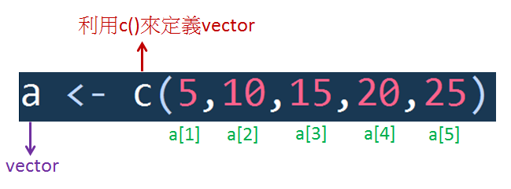

(小練習)利用**index**，取出特定的element吧：

```r
a[3]      # Ans: 15           (取第3個element)
a[1:3]    # Ans: 5 10 15      (取第1~第3個element)
a[c(2,4)] # Ans: 10 20        (取第2和第4個element)
```

在vector裡有一個需要注意的規則：「每一個element」都會是相同的型態！

```r
a <- c(1, "john", 3) # 若是把number和character同時放入vector裡，
a                    # R會自動將所有element的型態，轉變成character
```

```
## [1] "1"    "john" "3"
```

```r
b <- c(T, 3, F)      # logic和number在vector裡的話
b                    # T和F會被自動轉換成1和0，變成數字的vector
```

```
## [1] 1 3 0
```

當然，vector之間也可以進行數學運算：

```r
a <- c(7,8,6,9,5) # 建立一個number vector
b <- c(2,4,6,0,1) # 建立一個number vector

a * b             # a和b的第一個element相乘，第二個element相乘......
b^3               # 對b之中的每一個element三次方
b > 3             # 判斷b之中的哪些值大於 3 ，然後回傳 TRUE/FALSE
```

```
## [1] 14 32 36  0  5
## [1]   8  64 216   0   1
## [1] FALSE  TRUE  TRUE FALSE FALSE
```

## 類別變數 (factor)

`factor`的型態，主要用來表示「類別變數」(category variable)。  
(例如：性別(男、女)，年級(小一、小二….碩一、碩二)，地區(北、中、南、東)…等等。)  
在用R進行資料分析時，當遇到這類「類別變數」時，要轉換成`factor`的資料型態，再丟入模型(model)進行分析。

`factor`的資料型態和`vector`很相似，差別在於`factor`具有額外的類別屬性(Levels)。  
要建立factor的變數，可以使用`factor()`函式：

```r
gender <- c("boy", "girl", "boy", "boy", "girl")  # 建立一個character vector
gender <- factor(gender)   # 轉換成factor型態
gender                     # Levels的屬性代表: 在這個變數裡面，存在哪些類別
```

```
## [1] boy  girl boy  boy  girl
## Levels: boy girl
```

如果有一組類別變數，要查看裡面存在著哪些類別，可以用`levels()`函式：

```r
levels(gender)
```

```
## [1] "boy"  "girl"
```

## 列表(list)

還記得vector裡面，每一個element要相同型態的規定嗎？  
但有時候，我們會想要把不同資料型態的值，放到同一個變數裡面，那這時又該怎麼辦？  
在R裡面，有一種資料型態能解決這樣的問題，那就是列表(`list`)。  
舉個例子：一個人身上其實具備了許多資訊(性別，年齡，嗜好…)，可是這些資訊的型態不盡相同。因此，若我們想要儲存「一個人的所有資訊」，那就可以用`list`的資料型態(使用`list()`函式)：

```r
Dr.Lee <- list(gender="man", age=18, hobby=c("tease", "be teased"))
Dr.Lee        # list長什麼模樣呢～
```

```
## $gender
## [1] "man"
##
## $age
## [1] 18
##
## $hobby
## [1] "tease"     "be teased"
```

```r
str(Dr.Lee)   # 看一下list裡面的資訊～
```

```
## List of 3
##  $ gender: chr "man"
##  $ age   : num 18
##  $ hobby : chr [1:2] "tease" "be teased"
```

你可能已經注意到hobby這個變數。沒錯，list可以存放「任何型態」的變數，自然也包括vector。(當然也包括list)  
既然可以儲存資料，那也要可以把資料取出來才對！  
R裡面有一個神奇的符號`$`，用來取出特定的資料：

```r
Dr.Lee$hobby        # Dr.Lee的嗜好
Dr.Lee$age          # Dr.Lee的年紀
```

```
## [1] "tease"     "be teased"
## [1] 18
```

```r
Dr.Lee[[3]]         # 當然，也可以用index的方式
```

```
## [1] "tease"     "be teased"
```

```r
Dr.Lee[3]           # 然而，上面那行有兩個中括號，這行卻只有一個，看看結果有什麼不同吧！
```

```
## $hobby
## [1] "tease"     "be teased"
```

(小練習)試試看用`str()`，比較看看在list中，用“一個中括號:和”兩個中括號“，取出來的資料型態有什麼差別吧！

```r
str(Dr.Lee[[3]] )     # Ans:使用兩個中括號，取出來的資料是vector
str(Dr.Lee[3] )       # Ans:使用一個中括號，取出來的資料是list
```

# **3. matrix, data frame**

之所以會把`matrix`和`data frame`在一起，是因為它們有很多觀念都很相似，使用的手法也幾乎雷同。

## 矩陣(matrix)

R裡面定義矩陣的方式很簡單，就是用`matrix()`函式：

```r
a <- matrix(c(1:6), nrow=3, ncol=2) #建立一個3x2的矩陣，依照column分別填入1~6的值
a
```

```
##      [,1] [,2]
## [1,]    1    4
## [2,]    2    5
## [3,]    3    6
```

```r
b <- matrix(c(3:8), nrow=2, ncol=3) #建立一個2x3的矩陣，依照column分別填入3~8的值
b
```

```
##      [,1] [,2] [,3]
## [1,]    3    5    7
## [2,]    4    6    8
```

如果我要查看a裡面，(2,2)所對應的值是什麼，可以這麼做：

```r
a[2,2]
```

```
## [1] 5
```

當然，也可以查看b的「第一列」裡所有值：

```r
b[1, ]    # 欄"空白"
```

```
## [1] 3 5 7
```

矩陣相乘的符號是`%*%``：

```r
a %*% b #矩陣相乘
```

```
##      [,1] [,2] [,3]
## [1,]   19   29   39
## [2,]   26   40   54
## [3,]   33   51   69
```

和矩陣相關的運算函式：

(小練習)試試看這些函式的作用：

```r
#建立一個3x2的矩陣，隨機從1~100內填入6個值
a <- matrix(sample(1:100, size=6), nrow=3, ncol=2)
#建立一個2x3的矩陣，隨機從1~100內填入6個值
b <- matrix(sample(1:100, size=6), nrow=2, ncol=3)
#建立一個4x4的方陣，隨機從1~100內填入16個值
c <- matrix(sample(1:100, size=16), nrow=4, ncol=4)

t(a)       #轉置
diag(b)    #對角矩陣
det(c)     #計算行列式值
solve(c)   #反矩陣
```

## 資料框(data frame)

毫無疑問的，這是R語言裡最特別的功能之一：data frame！  
平常我們在分析資料，多半是使用Excel，打開裡面的Sheet，然後進行統計分析或計算。  
如果說，Excel對應的東西是Sheet，那R所對應的就是data frame。  
以下直接拿一個[資料](https://data.medicare.gov/api/views/c7us-v4mf/rows.csv?accessType=DOWNLOAD)進行介紹。

下載資料後，用Excel打開就會像這樣：

[figure not shown]

現在來把這個csv檔，匯入到R裡面，變成一個data frame：  
首先，找到右邊的「Import Dataset」，選取「From Text File」

[figure not shown]

去找剛剛下載的csv檔，選取之後會跳出這個畫面，點「Import」

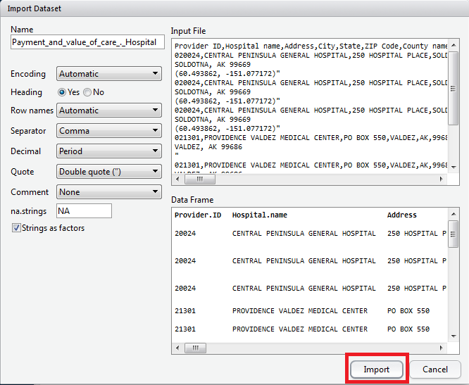

這樣就成功把資料匯入到R裡面，狀態就會像下圖一樣：

[figure not shown]

讓我們用`str()`查看這個資料，會發現資料型態為**data frame**，以及詳列出每一個變數的資訊：

```r
str(Payment_and_value_of_care_._Hospital)
```

```
## 'data.frame':    14301 obs. of  23 variables:
##  $ Provider.ID               : Factor w/ 4767 levels "010001","010005",..: 98 98 98 101 101 101 102 102 102 104 ...
##  $ Hospital.name             : Factor w/ 4572 levels " HIMA SAN PABLO BAYAMON",..: 612 612 612 3154 3154 3154 3146 3146 3146 2999 ...
##  $ Address                   : Factor w/ 4740 levels " CALLE CONCEPCION VERA AYALA #550 S",..: 2056 2056 2056 4705 4705 4705 2967 2967 2967 2 ...
##  $ City                      : Factor w/ 2891 levels "ABBEVILLE","ABERDEEN",..: 2403 2403 2403 2640 2640 2640 2346 2346 2346 1998 ...
##  $ State                     : Factor w/ 55 levels "AK","AL","AR",..: 1 1 1 1 1 1 1 1 1 1 ...
##  $ ZIP.Code                  : int  99669 99669 99669 99686 99686 99686 99664 99664 99664 99833 ...
##  $ County.name               : Factor w/ 1530 levels "","ABBEVILLE",..: 1 1 1 1 1 1 1 1 1 1 ...
##  $ Phone.number              : num  9.07e+09 9.07e+09 9.07e+09 9.08e+09 9.08e+09 ...
##  $ Payment.measure.name      : Factor w/ 3 levels "Payment for heart attack patients",..: 1 2 3 1 2 3 1 2 3 1 ...
##  $ Payment.measure.ID        : Factor w/ 3 levels "PAYM_30_AMI",..: 1 2 3 1 2 3 1 2 3 1 ...
##  $ Payment.category          : Factor w/ 5 levels "Greater than the National Average Payment",..: 5 3 3 5 5 5 5 5 5 5 ...
##  $ Denominator               : Factor w/ 924 levels "1,001","1,002",..: 924 665 917 924 924 924 924 924 924 924 ...
##  $ Payment                   : Factor w/ 6157 levels "","$10045.00",..: 1 990 576 1 1 1 1 1 1 1 ...
##  $ Lower.estimate            : Factor w/ 6194 levels "$10,011","$10,013",..: 6194 723 520 6194 6194 6194 6194 6194 6194 6194 ...
##  $ Higher.estimate           : Factor w/ 6313 levels "$10,269","$11,359",..: 6313 1532 599 6313 6313 6313 6313 6313 6313 6313 ...
##  $ Payment.footnote          : Factor w/ 4 levels "","1 - The number of cases/patients is too few to report.",..: 2 1 1 2 2 2 2 2 2 2 ...
##  $ Value.of.care.display.name: Factor w/ 4 levels "","Value of Care Heart Attack measure",..: 2 3 4 2 3 4 2 3 4 2 ...
##  $ Value.of.care.display.ID  : Factor w/ 4 levels "","MORT_PAYM_30_AMI",..: 2 3 4 2 3 4 2 3 4 2 ...
##  $ Value.of.care.category    : Factor w/ 11 levels "","Average mortality and average payment",..: 8 2 2 8 8 8 8 8 8 8 ...
##  $ Value.of.care.footnote    : Factor w/ 3 levels "","13 - Results cannot be calculated for this reporting period.",..: 2 1 1 2 2 2 2 2 2 2 ...
##  $ Measure.start.date        : Factor w/ 1 level "07/01/2011": 1 1 1 1 1 1 1 1 1 1 ...
##  $ Measure.End.Date          : Factor w/ 1 level "06/30/2014": 1 1 1 1 1 1 1 1 1 1 ...
##  $ Location                  : Factor w/ 4767 levels "#1 MEDICAL PARK DRIVE\nBENTON, AR 72015\n(34.572716, -92.585094)",..: 2074 2074 2074 4731 4731 4731 2986 2986 2986 4732 ...
```

又或者，可以利用`data.frame()`函式，創造自己的data frame：

```r
tmp <- data.frame(Student_ID=c(1,2,3,4,5),
                  name=c("Helen", "Lun", "Leon", "Kevin", "Tommy"),
                  score=c(80,36, 88.9, 97.5, 60))
tmp        # data frame的型態
```

```
##   Student_ID  name score
## 1          1 Helen  80.0
## 2          2   Lun  36.0
## 3          3  Leon  88.9
## 4          4 Kevin  97.5
## 5          5 Tommy  60.0
```

data frame裡有一些好用的手法，可以有效地協助我們達成目的。  
首先，先來一段程式碼：

```r
tmp[4,3]
```

```
## [1] 97.5
```

這裡所代表的意思是：

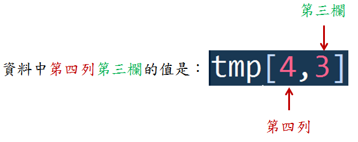

有沒有和矩陣很像？

因此，如果我們要看第一人的分數(第一列)：

```r
tmp[1, ]   # 在欄的地方"空白"
```

```
##   Student_ID  name score
## 1          1 Helen    80
```

又或者，我們要看所有人的分數(第三欄)：

```r
tmp[, 3]  # 在列的地方"空白"
```

```
## [1] 80.0 36.0 88.9 97.5 60.0
```

除此之外，還記得R裡面有個神奇符號`$`嗎？  
在data frame裡面，`$`可以用來指定「欄位名稱」，擷取該欄位的所有值：

```r
tmp$name     #查看所有人的名字
```

```
## [1] Helen Lun   Leon  Kevin Tommy
## Levels: Helen Kevin Leon Lun Tommy
```

但有時候我們會想要特定的資訊(例如“Leon”這個人的資訊)，那這時可以這麼做：

```r
tmp[tmp$name == "Leon", ]
```

```
##   Student_ID name score
## 3          3 Leon  88.9
```

以上包含了兩個步驟：我們先看`tmp$name == "Leon"`的結果：

```r
tmp$name == "Leon"
```

```
## [1] FALSE FALSE  TRUE FALSE FALSE
```

`tmp$name == "Leon"`這行指令，表示會去判斷所有人的名字(tmp$name)裡，是否有符合“Leon”的資料。如果有的話，回傳TRUE，不然就是FALSE。

第二步，把這行條件式放到data frame的「列」中，是TRUE的「那一列資料」就會顯示出來。  
換句話說，原本的這行程式碼`tmp[tmp$name == "Leon", ]`，其實同等於下面這行程式碼：

```r
tmp[c(FALSE, FALSE, TRUE, FALSE, FALSE), ]
```

```
##   Student_ID name score
## 3          3 Leon  88.9
```

# **總結**

在R裡面，比較嶄新而且實用的資料型態，就是`vector`，`list`以及`data frame`。以經驗來說，在資料處理/分析的過程中，若是能好好運用這三種資料型態，可以達到事半功倍的效果。  
除此之外，這篇文章有提到一些實用的函式，接下來會介紹更多常見的函式，包括：[**常見的函式、如何去下載想要的函式，如何去理解函式的狀態…等等**](http://www.rpubs.com/skydome20/R-Note3-function_and_package)。  
It’s still a long way to go~

# **(額外)關於賦值**

雖然在R中進行賦值時，除了使用符號`<-`以外，也可以使用`=`。  
但是在[**R的官方文件**](http://stat.ethz.ch/R-manual/R-patched/library/base/html/assignOps.html)，又或者是[**Google’s R Style Guide**](https://google.github.io/styleguide/Rguide.xml)中，都強調最好不要使用`=`，因為有時候會造成[**問題**](http://stackoverflow.com/questions/1741820/assignment-operators-in-r-and)。  
有興趣的話，可以參考以上連結，更進一步的了解。